# Tesco-Roman Ledanov

```python
# importing the standard libraries
import pandas as pd
import numpy as np
import matplotlib.pyplot as plt
import seaborn as sns
```

## Part I

```python
# reading in the data
transactions = pd.read_csv('./DS Assesment - Minimal 3/transactions.tsv', sep = '\t')
```

```python
# looking a bit at the data
transactions.head()
```

|  | transaction.value | gender | store.type |
| --- | --- | --- | --- |
| 0 | 33.80 | Male | Metro |
| 1 | 7.02 | Male | Superstore |
| 2 | 335.88 | Female | Extra |
| 3 | 79.02 | Male | Superstore |
| 4 | 354.15 | Male | Metro |

**Q1) What is the average transaction value?**

```python
print('The average transaction value is: {:.2f}'.format(transactions['transaction.value'].mean()))
```

```
The average transaction value is: 286.18
```

**Q2) Is there significant difference between spend in different store types?**

```python
store_avg = transactions.groupby('store.type')[['transaction.value']].mean()
```

```python
store_avg
```

| store.type | transaction.value |
| --- | --- |
| Express | 86.349468 |
| Extra | 533.165920 |
| Metro | 421.018131 |
| Superstore | 155.166490 |

```python
store_avg.reset_index(inplace = True)
```

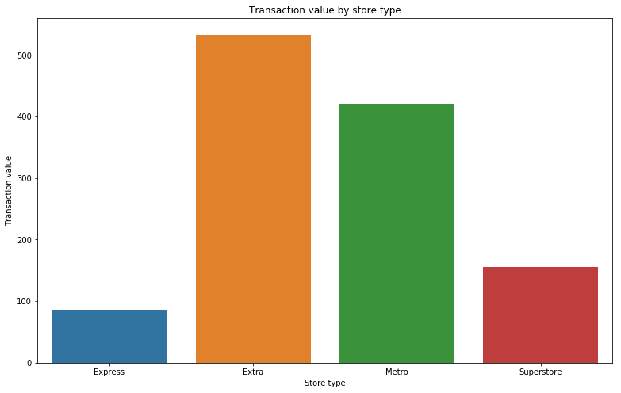

```python
plt.figure(figsize = (13,8))
sns.barplot(x = 'store.type', y = 'transaction.value', data = store_avg)
plt.title('Transaction value by store type')
plt.xlabel('Store type')
plt.ylabel('Transaction value');
```

It would appear that there is quite a significant difference in the average expenditure depending on the store type

## Part II

```python
content = pd.read_csv('./DS Assesment - Minimal 3/content_train.tsv', sep = '\t')
```

```python
content.head()
```

|  | customer.id | content_1 | content_2 | content_3 | content_4 | content_5 | content_6 | content_7 | content_8 | content_9 | ... | extra.total.spend | fandf.no.transactions | fandf.total.spend | petrol.no.transactions | petrol.total.spend | direct.no.transactions | direct.total.spend | gender | affluency | county |
| --- | --- | --- | --- | --- | --- | --- | --- | --- | --- | --- | --- | --- | --- | --- | --- | --- | --- | --- | --- | --- | --- |
| 0 | 1 | NaN | NaN | NaN | NaN | NaN | NaN | 0.0 | 0.0 | NaN | ... | 634.11 | 14 | 76.12 | 32 | 753.12 | 10 | 617.47 | Female | Mid | Surrey |
| 1 | 2 | NaN | NaN | NaN | 0.0 | NaN | 0.0 | NaN | NaN | 0.0 | ... | 679.78 | 13 | 142.74 | 28 | 37.86 | 51 | 2787.49 | Female | Mid | Greater Manchester |
| 2 | 3 | 0.0 | NaN | 0.0 | NaN | NaN | 0.0 | NaN | 0.0 | 0.0 | ... | 282.90 | 7 | 672.12 | 55 | 563.12 | 4 | 444.34 | Female | Low | Greater Manchester |
| 3 | 4 | NaN | 0.0 | NaN | 0.0 | NaN | 0.0 | NaN | NaN | 0.0 | ... | 5954.89 | 49 | 2394.10 | 56 | 912.70 | 24 | 5859.31 | Male | Mid | Brighton & Hove |
| 4 | 5 | 0.0 | NaN | NaN | 0.0 | 0.0 | 0.0 | 0.0 | NaN | NaN | ... | 3170.40 | 27 | 651.36 | 52 | 925.30 | 17 | 433.57 | Female | Low | Norfolk |

5 rows × 27 columns

```python
content.info()
```

```
<class 'pandas.core.frame.DataFrame'>
RangeIndex: 100000 entries, 0 to 99999
Data columns (total 27 columns):
customer.id                   100000 non-null int64
content_1                     46022 non-null float64
content_2                     42958 non-null float64
content_3                     27314 non-null float64
content_4                     38079 non-null float64
content_5                     44830 non-null float64
content_6                     49706 non-null float64
content_7                     38196 non-null float64
content_8                     38346 non-null float64
content_9                     48025 non-null float64
express.no.transactions       100000 non-null int64
express.total.spend           100000 non-null float64
metro.no.transactions         100000 non-null int64
metro.total.spend             100000 non-null float64
superstore.no.transactions    100000 non-null int64
superstore.total.spend        100000 non-null float64
extra.no.transactions         100000 non-null int64
extra.total.spend             100000 non-null float64
fandf.no.transactions         100000 non-null int64
fandf.total.spend             100000 non-null float64
petrol.no.transactions        100000 non-null int64
petrol.total.spend            100000 non-null float64
direct.no.transactions        100000 non-null int64
direct.total.spend            100000 non-null float64
gender                        100000 non-null object
affluency                     100000 non-null object
county                        100000 non-null object
dtypes: float64(16), int64(8), object(3)
memory usage: 20.6+ MB
```

```python
content.content_1.isna().sum()
```

```
53978
```

```python
# Data cleaning
# Since we are only concerned with content_1 in this model, we will drop the other content_x columns, and the customer.id column
content.drop(columns = content.iloc[:, 2:10], axis = 1, inplace = True)
content.drop(columns = 'customer.id', axis = 1, inplace = True)
content.head()
```

|  | content_1 | express.no.transactions | express.total.spend | metro.no.transactions | metro.total.spend | superstore.no.transactions | superstore.total.spend | extra.no.transactions | extra.total.spend | fandf.no.transactions | fandf.total.spend | petrol.no.transactions | petrol.total.spend | direct.no.transactions | direct.total.spend | gender | affluency | county |
| --- | --- | --- | --- | --- | --- | --- | --- | --- | --- | --- | --- | --- | --- | --- | --- | --- | --- | --- |
| 0 | NaN | 44 | 984.54 | 64 | 2121.46 | 21 | 78.56 | 39 | 634.11 | 14 | 76.12 | 32 | 753.12 | 10 | 617.47 | Female | Mid | Surrey |
| 1 | NaN | 49 | 514.98 | 79 | 56.28 | 39 | 2824.11 | 52 | 679.78 | 13 | 142.74 | 28 | 37.86 | 51 | 2787.49 | Female | Mid | Greater Manchester |
| 2 | 0.0 | 44 | 66.96 | 68 | 1766.38 | 50 | 2609.10 | 78 | 282.90 | 7 | 672.12 | 55 | 563.12 | 4 | 444.34 | Female | Low | Greater Manchester |
| 3 | NaN | 29 | 1425.38 | 49 | 689.62 | 53 | 945.63 | 81 | 5954.89 | 49 | 2394.10 | 56 | 912.70 | 24 | 5859.31 | Male | Mid | Brighton & Hove |
| 4 | 0.0 | 38 | 143.67 | 39 | 601.60 | 39 | 856.57 | 52 | 3170.40 | 27 | 651.36 | 52 | 925.30 | 17 | 433.57 | Female | Low | Norfolk |

```python
# Since observations where the consumer was not shown the card are useless to us for modeling purposes, we have no choice but to drop all the na's
content.dropna(inplace = True)
```

```python
content.info()
```

```
<class 'pandas.core.frame.DataFrame'>
Int64Index: 46022 entries, 2 to 99999
Data columns (total 18 columns):
content_1                     46022 non-null float64
express.no.transactions       46022 non-null int64
express.total.spend           46022 non-null float64
metro.no.transactions         46022 non-null int64
metro.total.spend             46022 non-null float64
superstore.no.transactions    46022 non-null int64
superstore.total.spend        46022 non-null float64
extra.no.transactions         46022 non-null int64
extra.total.spend             46022 non-null float64
fandf.no.transactions         46022 non-null int64
fandf.total.spend             46022 non-null float64
petrol.no.transactions        46022 non-null int64
petrol.total.spend            46022 non-null float64
direct.no.transactions        46022 non-null int64
direct.total.spend            46022 non-null float64
gender                        46022 non-null object
affluency                     46022 non-null object
county                        46022 non-null object
dtypes: float64(8), int64(7), object(3)
memory usage: 6.7+ MB
```

```python
# Checking that there are no negative transaction values
content.describe()
```

|  | content_1 | express.no.transactions | express.total.spend | metro.no.transactions | metro.total.spend | superstore.no.transactions | superstore.total.spend | extra.no.transactions | extra.total.spend | fandf.no.transactions | fandf.total.spend | petrol.no.transactions | petrol.total.spend | direct.no.transactions | direct.total.spend |
| --- | --- | --- | --- | --- | --- | --- | --- | --- | --- | --- | --- | --- | --- | --- | --- |
| count | 46022.000000 | 46022.000000 | 46022.000000 | 46022.000000 | 46022.000000 | 46022.000000 | 46022.000000 | 46022.000000 | 46022.000000 | 46022.000000 | 46022.000000 | 46022.000000 | 46022.000000 | 46022.000000 | 46022.000000 |
| mean | 0.010908 | 50.025205 | 767.416981 | 50.065838 | 1159.658331 | 50.009365 | 2824.632077 | 49.809852 | 2836.794687 | 30.510582 | 1040.920795 | 30.446395 | 572.870204 | 30.495415 | 2827.876428 |
| std | 0.103870 | 19.155164 | 892.602536 | 19.208225 | 1388.689747 | 19.058458 | 3355.205835 | 19.000328 | 3406.890330 | 18.220019 | 1393.085678 | 18.210663 | 779.280040 | 18.199900 | 3808.302518 |
| min | 0.000000 | 0.000000 | 0.000000 | 0.000000 | 0.000000 | 0.000000 | 0.000000 | 0.000000 | 0.000000 | 0.000000 | 0.000000 | 0.000000 | 0.000000 | 0.000000 | 0.000000 |
| 25% | 0.000000 | 37.000000 | 208.822500 | 37.000000 | 308.027500 | 37.000000 | 762.705000 | 37.000000 | 764.462500 | 17.000000 | 191.212500 | 17.000000 | 105.495000 | 17.000000 | 513.070000 |
| 50% | 0.000000 | 50.000000 | 490.935000 | 50.000000 | 733.880000 | 50.000000 | 1801.875000 | 50.000000 | 1788.525000 | 30.000000 | 587.970000 | 30.000000 | 320.075000 | 30.000000 | 1572.675000 |
| 75% | 0.000000 | 63.000000 | 1004.677500 | 63.000000 | 1496.690000 | 63.000000 | 3662.412500 | 63.000000 | 3679.332500 | 43.000000 | 1350.437500 | 43.000000 | 737.177500 | 43.000000 | 3677.512500 |
| max | 1.000000 | 139.000000 | 19714.000000 | 140.000000 | 21864.790000 | 133.000000 | 73988.490000 | 129.000000 | 82972.690000 | 109.000000 | 40018.310000 | 101.000000 | 13510.060000 | 113.000000 | 76195.410000 |

```python
# Dealing with the categorical variables
content.head()
content['county'].value_counts()
from sklearn.preprocessing import LabelEncoder
encoder = LabelEncoder()

# transforming affluency with label encoder because it is ordinal
content['affluency'] = encoder.fit_transform(content['affluency'])

# Then transforming the county and gender columns into dummy variables
content = pd.get_dummies(content, prefix_sep='.')
```

```python
content.head()
```

|  | content_1 | express.no.transactions | express.total.spend | metro.no.transactions | metro.total.spend | superstore.no.transactions | superstore.total.spend | extra.no.transactions | extra.total.spend | fandf.no.transactions | ... | county.Warwickshire | county.West Berkshire | county.West Midlands | county.West Sussex | county.West Yorkshire | county.Wiltshire | county.Windsor and Maidenhead | county.Wokingham | county.Worcestershire | county.York |
| --- | --- | --- | --- | --- | --- | --- | --- | --- | --- | --- | --- | --- | --- | --- | --- | --- | --- | --- | --- | --- | --- |
| 2 | 0.0 | 44 | 66.96 | 68 | 1766.38 | 50 | 2609.10 | 78 | 282.90 | 7 | ... | 0 | 0 | 0 | 0 | 0 | 0 | 0 | 0 | 0 | 0 |
| 4 | 0.0 | 38 | 143.67 | 39 | 601.60 | 39 | 856.57 | 52 | 3170.40 | 27 | ... | 0 | 0 | 0 | 0 | 0 | 0 | 0 | 0 | 0 | 0 |
| 5 | 0.0 | 28 | 367.26 | 57 | 130.24 | 29 | 671.60 | 18 | 204.80 | 63 | ... | 0 | 0 | 0 | 0 | 1 | 0 | 0 | 0 | 0 | 0 |
| 7 | 0.0 | 47 | 186.19 | 82 | 263.43 | 56 | 274.20 | 87 | 14829.60 | 18 | ... | 0 | 0 | 0 | 0 | 0 | 0 | 0 | 0 | 0 | 0 |
| 9 | 0.0 | 56 | 1947.77 | 45 | 2460.47 | 51 | 9436.17 | 33 | 573.02 | 0 | ... | 0 | 0 | 0 | 0 | 0 | 0 | 0 | 0 | 0 | 0 |

5 rows × 108 columns

```python
# Setting our target variable to y
y = content['content_1']
X = content.drop('content_1', axis = 1)
```

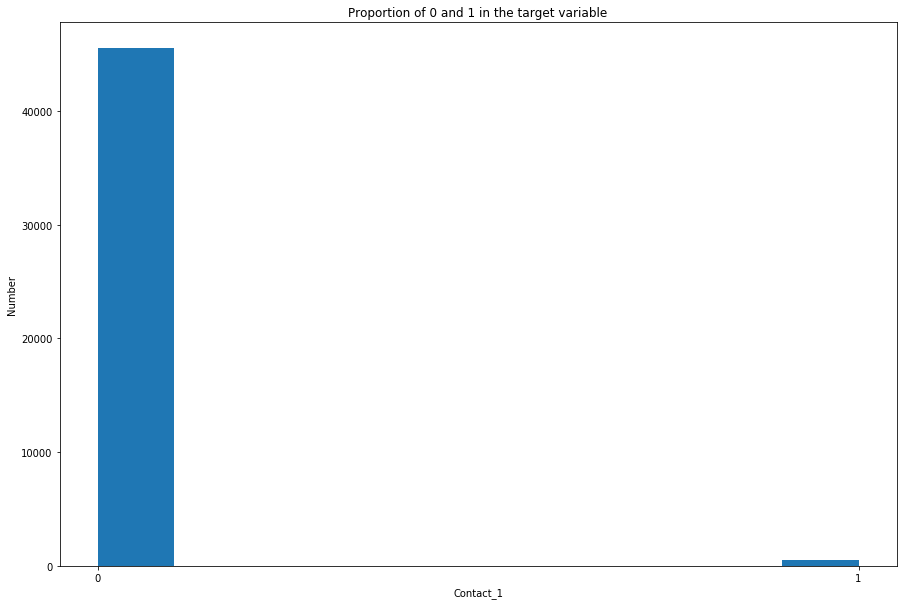

```python
# We must keep in mind that we have imbalanced classes in this example, so accuracy will not be of much use to us
y.value_counts()

plt.figure(figsize = (15,10))
plt.hist(y)
plt.title('Proportion of 0 and 1 in the target variable')
plt.xticks(ticks= [0,1], labels = [0,1])
plt.xlabel('Contact_1')
plt.ylabel('Number');
```

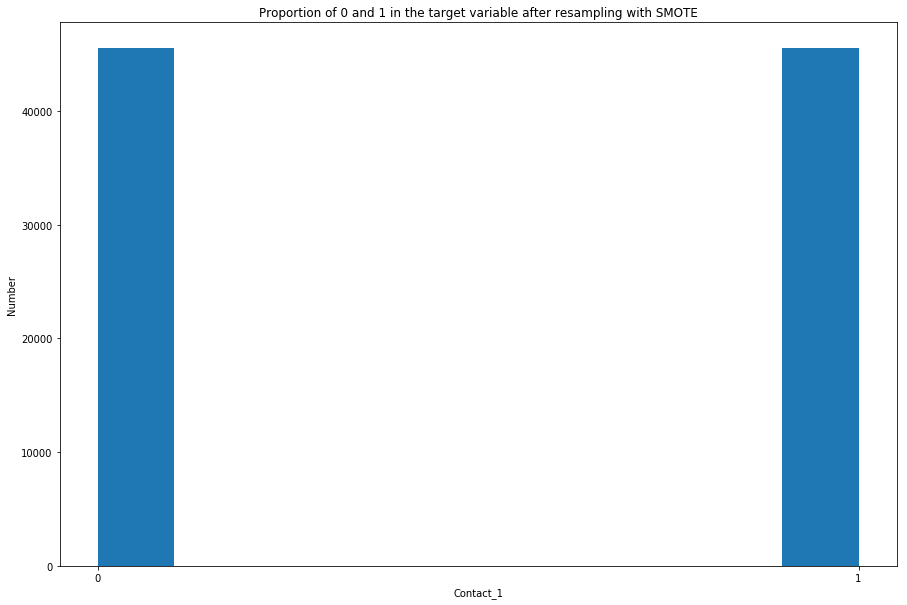

```python
# So we choose to use SMOTE, the synthetic minority oversampling technique to try and balance the class
from imblearn.over_sampling import SMOTE

sm = SMOTE(random_state = 0)
X_res, y_res = sm.fit_sample(X,y)

plt.figure(figsize = (15,10))
plt.hist(y_res)
plt.title('Proportion of 0 and 1 in the target variable after resampling with SMOTE')
plt.xticks(ticks= [0,1], labels = [0,1])
plt.xlabel('Contact_1')
plt.ylabel('Number');
```

```python
# Splitting the data into a train-validation set
from sklearn.model_selection import train_test_split
X_train, X_test, y_train, y_test = train_test_split(X_res, y_res, test_size = 0.2, stratify = y_res, random_state = 0)
```

```python
# Standardizing the data
from sklearn.preprocessing import StandardScaler

ss = StandardScaler()
X_train = ss.fit_transform(X_train)
X_test = ss.transform(X_test)
```

```python
# Finding the top correlations with the target variable, contact_1
corr_matrix = X.corrwith(y)
```

```python
# it appears that, upon initial inspection, the design of this card was far more appealing to females than males,
# and that this is pretty much the only factor involved here
corr_matrix.sort_values(ascending = False)
```

```
gender.Female                       0.044758
county.Warwickshire                 0.013892
county.Luton                        0.012340
county.Torbay                       0.011895
county.Rutland                      0.011783
county.Darlington                   0.010806
county.Reading                      0.009469
county.Cheshire West and Chester    0.009365
county.East Sussex                  0.008536
county.Northumberland               0.008459
county.West Midlands                0.008143
petrol.no.transactions              0.008029
county.Swindon                      0.007340
county.Central Bedfordshire         0.006873
county.Isle of Wight                0.006791
county.Poole                        0.006037
county.Somerset                     0.005291
county.Brighton & Hove              0.005259
county.Devon                        0.005043
petrol.total.spend                  0.004612
county.Peterborough                 0.004566
county.Hampshire                    0.004467
superstore.total.spend              0.004320
county.North Lincolnshire           0.004303
county.Plymouth                     0.004014
county.Blackpool                    0.003554
county.West Sussex                  0.003514
county.Gloucestershire              0.003503
county.Suffolk                      0.003083
county.Portsmouth                   0.002939
                                      ...
affluency                          -0.003050
county.Kent                        -0.003109
direct.total.spend                 -0.003616
county.Merseyside                  -0.003749
county.South Gloucestershire       -0.003933
county.North Somerset              -0.003982
county.Cumbria                     -0.004169
county.Medway                      -0.004198
county.South Yorkshire             -0.004245
fandf.no.transactions              -0.004619
county.Lincolnshire                -0.004902
county.Lancashire                  -0.004903
county.Nottingham                  -0.005186
county.Bristol                     -0.005433
county.Tyne and Wear               -0.005490
county.Blackburn with Darwen       -0.005524
county.West Berkshire              -0.005759
county.East Riding of Yorkshire    -0.005944
county.Thurrock                    -0.005945
county.Middlesbrough               -0.006222
county.Hertfordshire               -0.006316
county.Surrey                      -0.006596
extra.no.transactions              -0.006810
county.Stoke-on-Trent              -0.007024
county.Leicestershire              -0.007867
county.Nottinghamshire             -0.008066
direct.no.transactions             -0.008089
county.Staffordshire               -0.008806
extra.total.spend                  -0.008957
gender.Male                        -0.044758
Length: 107, dtype: float64
```

```python
# Since we wish to predict the value of content_1, which is a binary variable, we will use a logistic regression model
from sklearn.linear_model import LogisticRegressionCV
from sklearn.model_selection import GridSearchCV
```

```python
model = LogisticRegressionCV()
```

```python
model.fit(X_train, y_train)
```

```
LogisticRegressionCV(Cs=10, class_weight=None, cv=None, dual=False,
           fit_intercept=True, intercept_scaling=1.0, max_iter=100,
           multi_class='ovr', n_jobs=1, penalty='l2', random_state=None,
           refit=True, scoring=None, solver='lbfgs', tol=0.0001, verbose=0)
```

```python
# Evaluating the model
```

```python
from sklearn.metrics import confusion_matrix, classification_report, roc_auc_score, roc_curve
```

```python
print("Accuracy on the training set: {}".format(model.score(X_train, y_train)))
print("Accuracy on the test set: {}".format(model.score(X_test, y_test)))

# getting the predictions
y_pred = model.predict(X_test)
```

```
Accuracy on the training set: 0.6417234182776801
Accuracy on the test set: 0.6436731107205624
```

```python
cm = confusion_matrix(y_test, y_pred)
tn, fp, fn, tp = cm.ravel()
print("True Positives: {}".format(tp))
print("True Negatives: {}".format(tn))
print("False Positives: {}".format(fp))
print("False Negatives: {}".format(fn))
cm
print(classification_report(y_test, y_pred))
```

```
True Positives: 6169
True Negatives: 5551
False Positives: 3553
False Negatives: 2935
             precision    recall  f1-score   support

        0.0       0.65      0.61      0.63      9104
        1.0       0.63      0.68      0.66      9104

avg / total       0.64      0.64      0.64     18208
```

```python
# getting the coefficients from the model, so we can see which features the model thinks are most important
logistic_features = pd.DataFrame({'feature': X.columns,
            'coefficient': model.coef_[0]}).sort_values('coefficient', ascending = False)
# getting the most important features
top_features = logistic_features[abs(logistic_features['coefficient'])> 0.1]
```

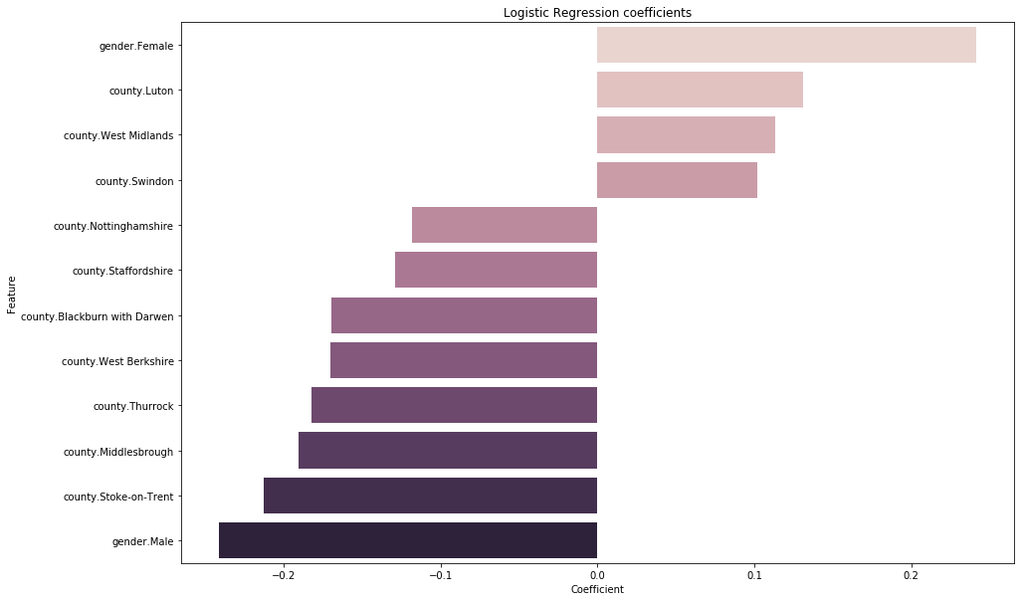

```python
plt.figure(figsize = (15,10))
sns.barplot(x = 'coefficient', y = 'feature', data = top_features, palette = sns.cubehelix_palette(12))
plt.title('Logistic Regression coefficients')
plt.xlabel('Coefficient')
plt.ylabel('Feature');
```

```python
# we can also try a random forest
from sklearn.ensemble import RandomForestClassifier
```

```python
forest = RandomForestClassifier()
forest.fit(X_train, y_train)
print("Random forest training accuracy: {}".format(forest.score(X_train, y_train)))
print("Random forest test accuracy: {}".format(forest.score(X_test, y_test)))


# getting the predictions
y_pred_forest = forest.predict(X_test)

cm = confusion_matrix(y_test, y_pred_forest)
tn, fp, fn, tp = cm.ravel()
print("True Positives: {}".format(tp))
print("True Negatives: {}".format(tn))
print("False Positives: {}".format(fp))
print("False Negatives: {}".format(fn))
cm
print(classification_report(y_test, y_pred_forest))
```

```
Random forest training accuracy: 0.999286028119508
Random forest test accuracy: 0.9944529876977153
True Positives: 9005
True Negatives: 9102
False Positives: 2
False Negatives: 99
             precision    recall  f1-score   support

        0.0       0.99      1.00      0.99      9104
        1.0       1.00      0.99      0.99      9104

avg / total       0.99      0.99      0.99     18208
```

```python
# getting the coefficients from the model, so we can see which features the model thinks are most important
forest_features = pd.DataFrame({'feature': X.columns,
            'coefficient': forest.feature_importances_}).sort_values('coefficient', ascending = False)
```

```python
# getting the top 12 features
forest_features = forest_features[:12]
```

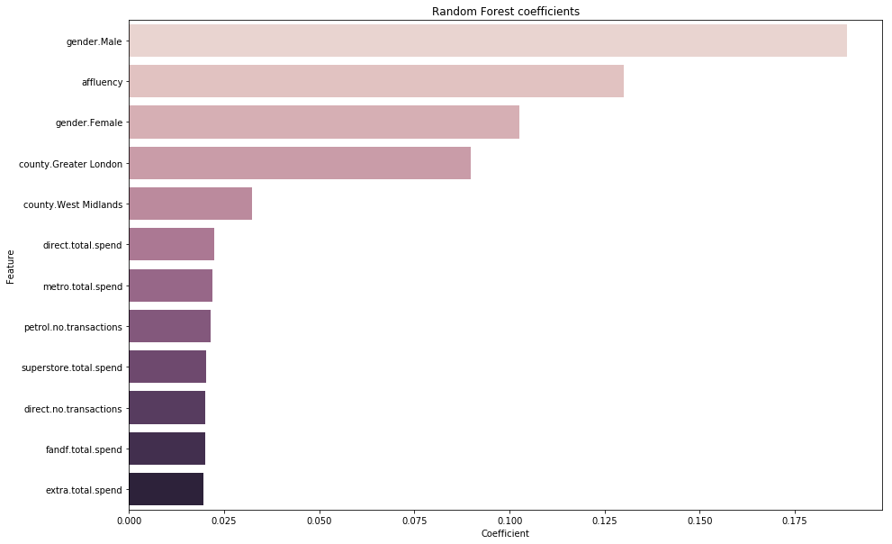

```python
plt.figure(figsize = (15,10))
sns.barplot(x = 'coefficient', y = 'feature', data = forest_features, palette = sns.cubehelix_palette(12))
plt.title('Random Forest coefficients')
plt.xlabel('Coefficient')
plt.ylabel('Feature');
```

2.) affluency

4.) Living in the Greater London area

You can see that the large amount of counties in the data seemed to 'confuse' the logistic regression, whereas the decision tree is easily able to 'see through' the swath of counties and find the truly important features

Q4) Please give a high-level description of how you would create a production system to deliver the most relevant content card to the user on the website.

I would use the AWS Kinesis platform, so that we could also use the other parts of the AWS infrastructure.